# WQD7004_GroupProject

## Group No.: 10

## Group Members

- LINGYU MENG (S2131391)
- HUIJUN LIU (S2142285)
- ZUOGE CHEN (S2125783)
- KELVIIN RAJJ KARUPAYA (S2151665)
- RUIXUE ZHANG (S2142119)

## Dataset

- Title: German Credit Risk
- Year: 2020
- Content: This dataset classifies people described by a set of attributes as good or bad credit risks.
- Source: https://www.kaggle.com/datasets/kabure/german-credit-data-with-risk

# 1 Introduction

In this dataset, each entry represents a person who takes a credit by a bank. Each person is classified as good or bad credit risks according to the set of attributes.

## 1.1 Project Objective

To manage and avoid the credit risk of users.

## 1.2 Project Question

- predict credit amount (regression)
- what variables most related to the credit amount? (classification)
- What level of risk does the customer belong to？
- What is the credit limit of the customer？

# 2 Data Pre-processing

## 2.1 Data Understanding

### Import libraries

```r
library(dplyr)
library(readr)
library(VIM)
library(missForest)
library(Hmisc)
library(caret)
library(ggplot2)
library(e1071)
library(klaR)
library(nnet)
library(Metrics)
library(rpart)
library(rpart.plot)
library(tidyverse)
library(skimr)
library(caret)
library(pROC)
library(DataExplorer)
```

### Read data

```r
df = read.csv(file.choose())
#Delete the 1st column which is used for indexing.
df=df[,-1]
head(df)
```

```
##   Age    Sex Job Housing Saving.accounts Checking.account Credit.amount
## 1  67   male   2     own            <NA>           little          1169
## 2  22 female   2     own          little         moderate          5951
## 3  49   male   1     own          little             <NA>          2096
## 4  45   male   2    free          little           little          7882
## 5  53   male   2    free          little           little          4870
## 6  35   male   1    free            <NA>             <NA>          9055
##   Duration             Purpose Risk
## 1        6            radio/TV good
## 2       48            radio/TV  bad
## 3       12           education good
## 4       42 furniture/equipment good
## 5       24                 car  bad
## 6       36           education good
```

### See the structure of dataset

```r
str(df)
```

```
## 'data.frame':    1000 obs. of  10 variables:
##  $ Age             : int  67 22 49 45 53 35 53 35 61 28 ...
##  $ Sex             : chr  "male" "female" "male" "male" ...
##  $ Job             : int  2 2 1 2 2 1 2 3 1 3 ...
##  $ Housing         : chr  "own" "own" "own" "free" ...
##  $ Saving.accounts : chr  NA "little" "little" "little" ...
##  $ Checking.account: chr  "little" "moderate" NA "little" ...
##  $ Credit.amount   : int  1169 5951 2096 7882 4870 9055 2835 6948 3059 5234 ...
##  $ Duration        : int  6 48 12 42 24 36 24 36 12 30 ...
##  $ Purpose         : chr  "radio/TV" "radio/TV" "education" "furniture/equipment" ...
##  $ Risk            : chr  "good" "bad" "good" "good" ...
```

## 2.2 Handle missing data

### Check missing values

```r
print(paste('Complete obs.:',sum(complete.cases(df))))
```

```
## [1] "Complete obs.: 522"
```

- Distribution of NAs (by column):

```r
colSums(is.na(df))
```

```
##              Age              Sex              Job          Housing
##                0                0                0                0
##  Saving.accounts Checking.account    Credit.amount         Duration
##              183              394                0                0
##          Purpose             Risk
##                0                0
```

- Check if any missing value is “” type

```r
colSums(df=="")
```

```
##              Age              Sex              Job          Housing
##                0                0                0                0
##  Saving.accounts Checking.account    Credit.amount         Duration
##               NA               NA                0                0
##          Purpose             Risk
##                0                0
```

### Visualisation of missing part

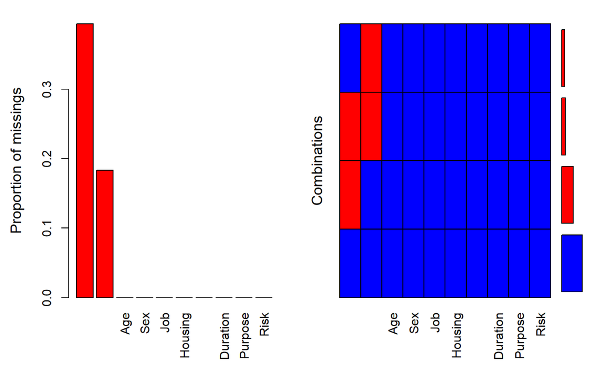

```
##
##  Variables sorted by number of missings:
##          Variable Count
##  Checking.account 0.394
##   Saving.accounts 0.183
##               Age 0.000
##               Sex 0.000
##               Job 0.000
##           Housing 0.000
##     Credit.amount 0.000
##          Duration 0.000
##           Purpose 0.000
##              Risk 0.000
```

```r
aggr(df,labels=names(df),col=c('blue','red'),
     numbrs=T,sortVars=T)
```

As shown above, Saving.accounts & Check.account contain missing values, and red color presents missing part.

### Predict and impute NAs

**Step 1: Convert chr variables to factor type**

```r
df1 <- df
df1$Sex <- as.factor(df1$Sex)
df1$Job <- as.ordered(df1$Job)
df1$Housing <- as.factor(df1$Housing)
df1$Saving.accounts <- as.ordered(df1$Saving.accounts)
df1$Checking.account <- as.ordered(df1$Checking.account)
df1$Purpose <- as.factor(df1$Purpose)
df1$Risk <- as.ordered(df1$Risk)
```

**Step 2: Impute NAs using missForest**

**missForest** is used to impute missing values particularly in the case of mixed-type data. It can be used to impute **continuous and/or categorical** data including complex interactions and nonlinear relations. It yields an out-of-bag (OOB) imputation error estimate. Moreover, it can be run parallel to save computation time.

```r
df.mis <- df1[!complete.cases(df1),]
df.train <- df1[complete.cases(df1),]
set.seed(42)
df.imp <- missForest(xmis = df.mis, xtrue = df.train, maxiter = 10, ntree = 200)
message('Out of Bag error: ', df.imp$OOBerror)
```

```
## Out of Bag error: 00.089277066758907
```

**Save imputation result**

```r
df.nomis <- df1
df.nomis[!complete.cases(df.nomis),] <- df.imp$ximp
```

**Saving.Account values distribution after imputation:**

```r
table(df.nomis$Saving.accounts)
```

```
##
##     little   moderate quite rich       rich
##        739        113         92         56
```

**Checking.Account values distribution after imputation:**

```r
table(df.nomis$Checking.account)
```

```
##
##   little moderate     rich
##      360      489      151
```

## 2.3 Smooth noisy data (Not yet decided)

- Save cleaned dataset

```r
write.csv(df.nomis,file = 'german_credit_data_rmna.csv',row.names=F)
```

- Summary dataset

```r
summary(df.nomis)
```

```
##       Age            Sex      Job     Housing      Saving.accounts
##  Min.   :19.00   female:310   0: 22   free:108   little    :739
##  1st Qu.:27.00   male  :690   1:200   own :713   moderate  :113
##  Median :33.00                2:630   rent:179   quite rich: 92
##  Mean   :35.55                3:148              rich      : 56
##  3rd Qu.:42.00
##  Max.   :75.00
##
##  Checking.account Credit.amount      Duration                   Purpose
##  little  :360     Min.   :  250   Min.   : 4.0   car                :337
##  moderate:489     1st Qu.: 1366   1st Qu.:12.0   radio/TV           :280
##  rich    :151     Median : 2320   Median :18.0   furniture/equipment:181
##                   Mean   : 3271   Mean   :20.9   business           : 97
##                   3rd Qu.: 3972   3rd Qu.:24.0   education          : 59
##                   Max.   :18424   Max.   :72.0   repairs            : 22
##                                                  (Other)            : 24
##    Risk
##  bad :300
##  good:700
##
##
##
##
##
```

### Descriptions of cleaned dataset

- Age: (quantitative, in years)
- Sex: (dichotomous: female, male)
- Job: (ordinal: 0 - unskilled and non-resident, 1 - unskilled and resident, 2 - skilled, 3 - highly skilled)
- Housing: (nominal: own, rent, or free)
- Saving.accounts: (ordinal: little, moderate, quite rich, rich) - Status of existing saving account.
- Checking.account: (ordinal: little, moderate, rich) - Status of existing checking account.
- Credit.amount: (quantitative, in D-mark) The maximum amount that the bank is committed to lend.
- Duration: (quantitative, in month) The specified time to pay the credit.
- Purpose: (nominal: car, furniture/equipment, radio/TV, domestic appliances, repairs, education, business, vacation/others) - Reasons to get a loan.
- Risk: (dichotomous : good, bad)

# 3 Exploratory Data Analysis

## 3.1 show the relationship between the duration of credit and the credit amount

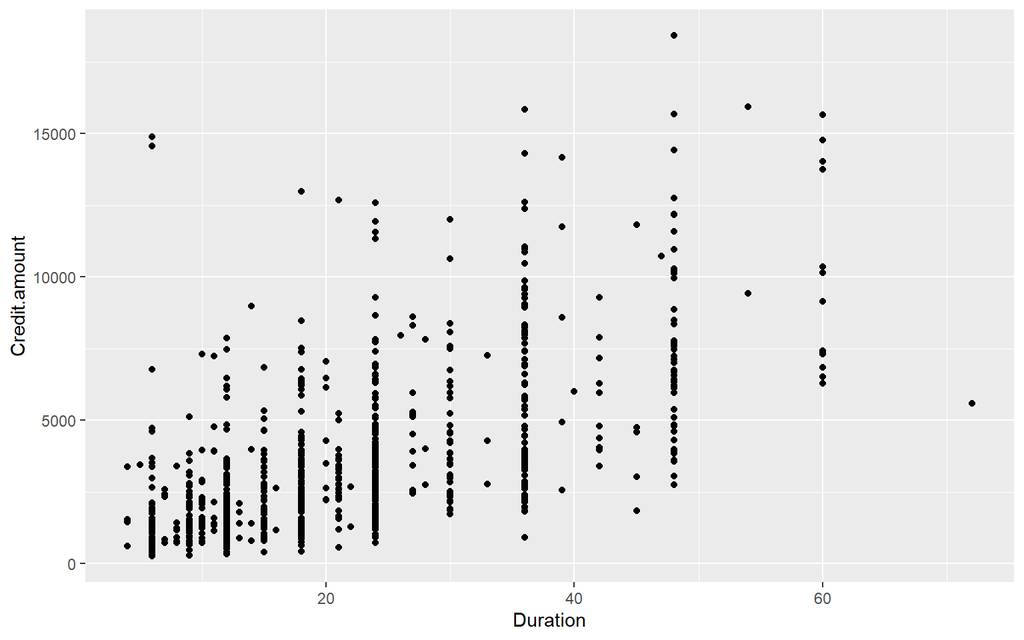

```r
Dur_Cred_Plot<-ggplot(df.nomis, aes(x=Duration, y=Credit.amount))+geom_point()
Dur_Cred_Plot
```

## 3.2 show the relationship between the sex and the credit amount

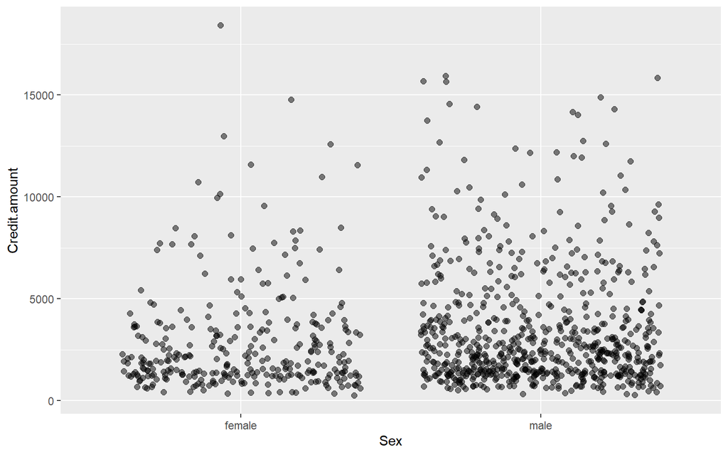

```r
Sex_Cred_Plot<-ggplot(df.nomis,aes(x=Sex, y=Credit.amount))+geom_jitter(size=2, alpha=0.5)
Sex_Cred_Plot
```

## 3.3 analyse the relationship between duration of credit and age

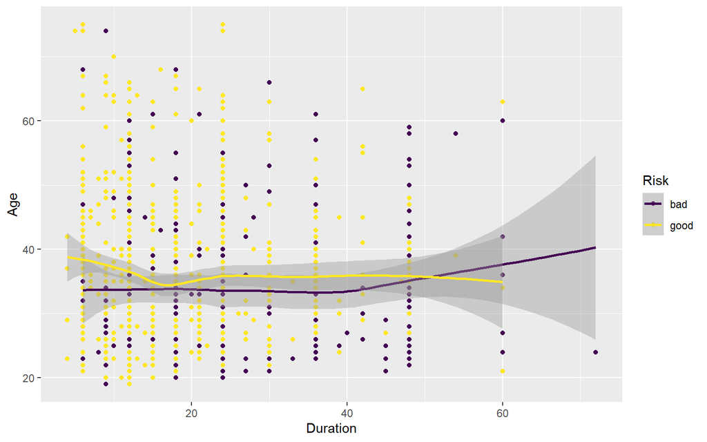

```r
Dur_Age_Plot<-ggplot(df.nomis,aes(x=Duration, y=Age, color=Risk))+geom_point()+geom_smooth()
Dur_Age_Plot
```

## 3.4 display points in scatter plot for bad and good loans

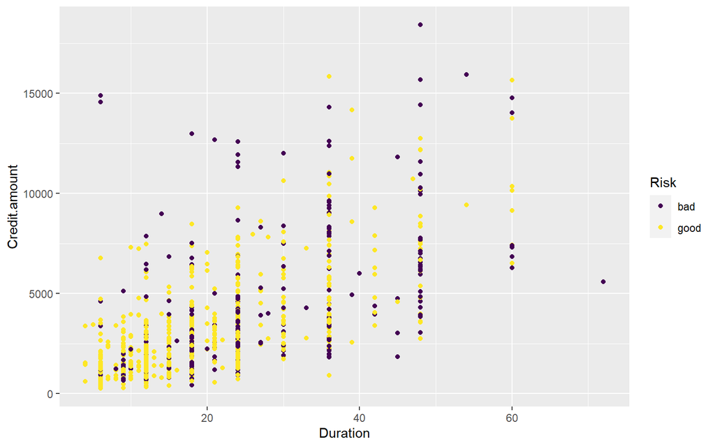

```r
Dur_Cred_Risk_Plot<-ggplot(df.nomis,aes(x=Duration,y=Credit.amount))+geom_point(aes(color=Risk))
Dur_Cred_Risk_Plot
```

## 3.5 use faceting to split entire graph into 2 separate panels for each, good and bads loans

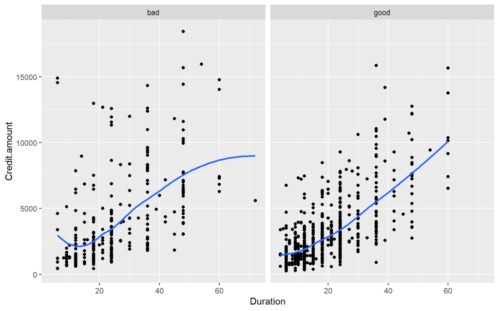

```r
Dur_Cred_Risk_facetPlot<-ggplot(df.nomis,aes(x=Duration, y=Credit.amount))+geom_point()+geom_smooth(se=F)+
  facet_grid(.~Risk)
Dur_Cred_Risk_facetPlot
```

## 3.6 check how the Job variable impacts the credit

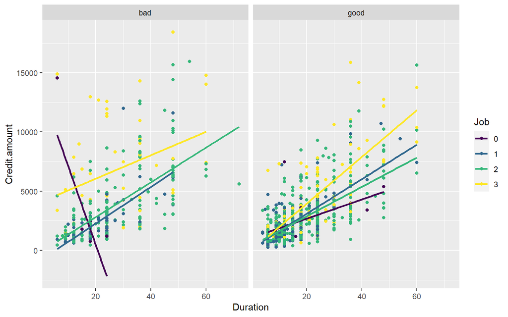

```r
Dur_Cred_Risk_Job_Plot<-ggplot(df.nomis,aes(x=Duration, y=Credit.amount, color=Job))+geom_point()+geom_smooth(se=F, method="lm")+
  facet_grid(.~Risk)
Dur_Cred_Risk_Job_Plot
```

## 3.7 facet to split the graph into the 4 type job variables

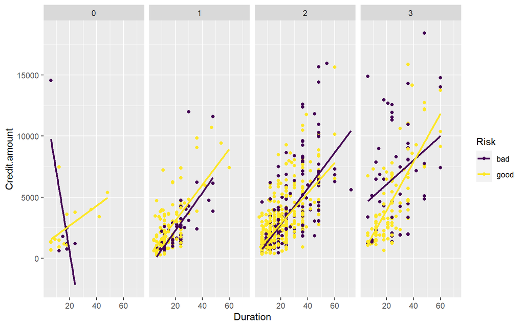

```r
Dur_Cred_Risk_Job_facetPlot<-ggplot(df.nomis,aes(x=Duration, y=Credit.amount, color=Risk))+geom_point()+geom_smooth(se=F, method="lm")+
  facet_grid(.~Job)
Dur_Cred_Risk_Job_facetPlot
```

## 3.8 show relationship between the savings account and credit amount

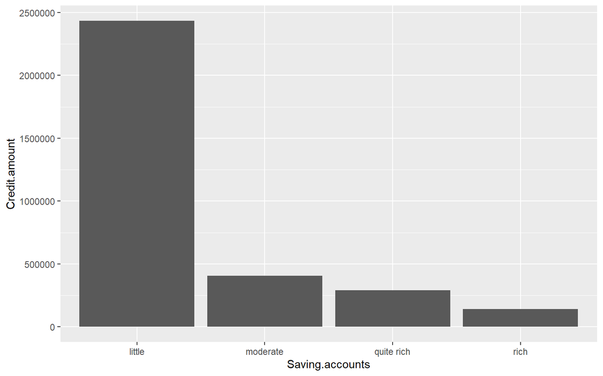

```r
Sav_Cred_Plot<-ggplot(df.nomis,aes(x=Saving.accounts, y=Credit.amount))+geom_bar(stat="identity")
Sav_Cred_Plot
```

## 3.9 show the good and bad loans in each savings account category

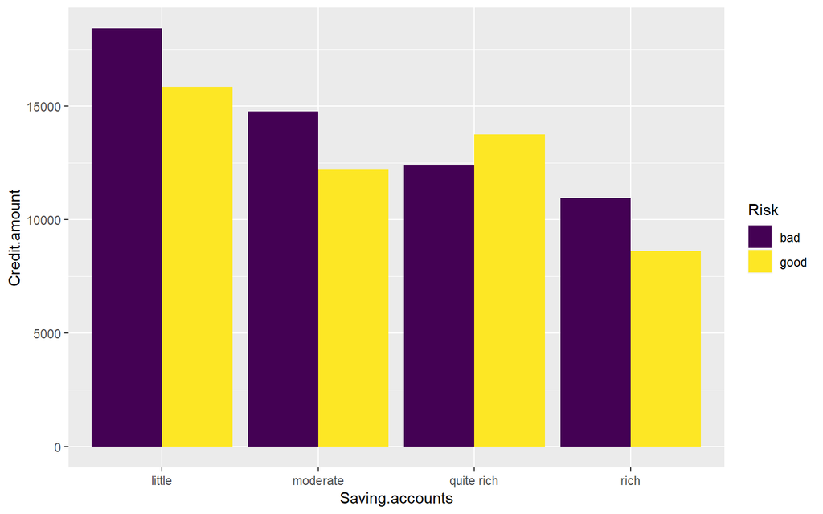

```r
Sav_Cred_Risk_Plot<-ggplot(df.nomis,aes(x=Saving.accounts, y=Credit.amount, fill=Risk))+geom_bar(stat="identity", position=position_dodge())
Sav_Cred_Risk_Plot
```

## 3.10 analyse the good and bad loans in the relationship between duration of credit and credit amount using the housing variable

```r
Dur_Cred_House_Risk<-ggplot(df.nomis,aes(x=Duration, y=Credit.amount))+geom_point()+geom_smooth()+
  facet_grid(Housing~Risk)
```

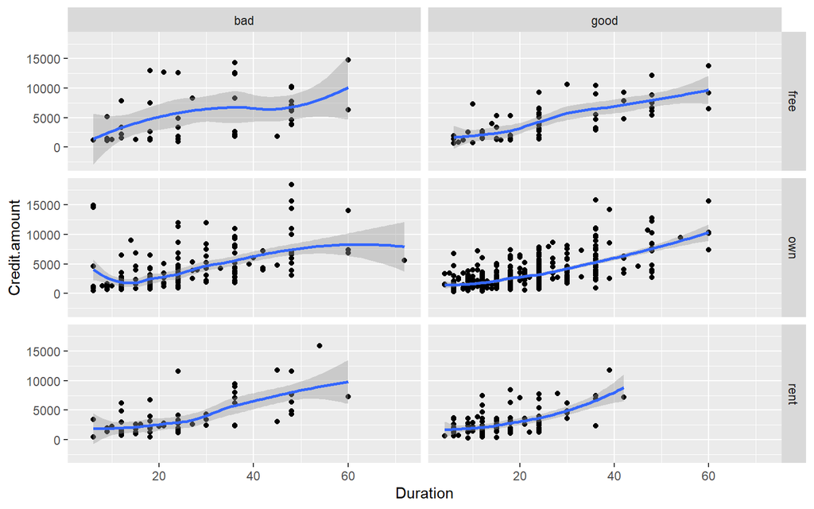

```r
Dur_Cred_House_Risk
```

# 4 Modeling

## 4.1 Regression Model predict credit amount (regression)

```r
skim(df.nomis)
```

Data summary

| Name | df.nomis |
| --- | --- |
| Number of rows | 1000 |
| Number of columns | 10 |
| _______________________ |  |
| Column type frequency: |  |
| factor | 7 |
| numeric | 3 |
| ________________________ |  |
| Group variables | None |

**Variable type: factor**

| skim_variable | n_missing | complete_rate | ordered | n_unique | top_counts |
| --- | --- | --- | --- | --- | --- |
| Sex | 0 | 1 | FALSE | 2 | mal: 690, fem: 310 |
| Job | 0 | 1 | TRUE | 4 | 2: 630, 1: 200, 3: 148, 0: 22 |
| Housing | 0 | 1 | FALSE | 3 | own: 713, ren: 179, fre: 108 |
| Saving.accounts | 0 | 1 | TRUE | 4 | lit: 739, mod: 113, qui: 92, ric: 56 |
| Checking.account | 0 | 1 | TRUE | 3 | mod: 489, lit: 360, ric: 151 |
| Purpose | 0 | 1 | FALSE | 8 | car: 337, rad: 280, fur: 181, bus: 97 |
| Risk | 0 | 1 | TRUE | 2 | goo: 700, bad: 300 |

**Variable type: numeric**

| skim_variable | n_missing | complete_rate | mean | sd | p0 | p25 | p50 | p75 | p100 | hist |
| --- | --- | --- | --- | --- | --- | --- | --- | --- | --- | --- |
| Age | 0 | 1 | 35.55 | 11.38 | 19 | 27.0 | 33.0 | 42.00 | 75 | ▇▆▃▁▁ |
| Credit.amount | 0 | 1 | 3271.26 | 2822.74 | 250 | 1365.5 | 2319.5 | 3972.25 | 18424 | ▇▂▁▁▁ |
| Duration | 0 | 1 | 20.90 | 12.06 | 4 | 12.0 | 18.0 | 24.00 | 72 | ▇▇▂▁▁ |

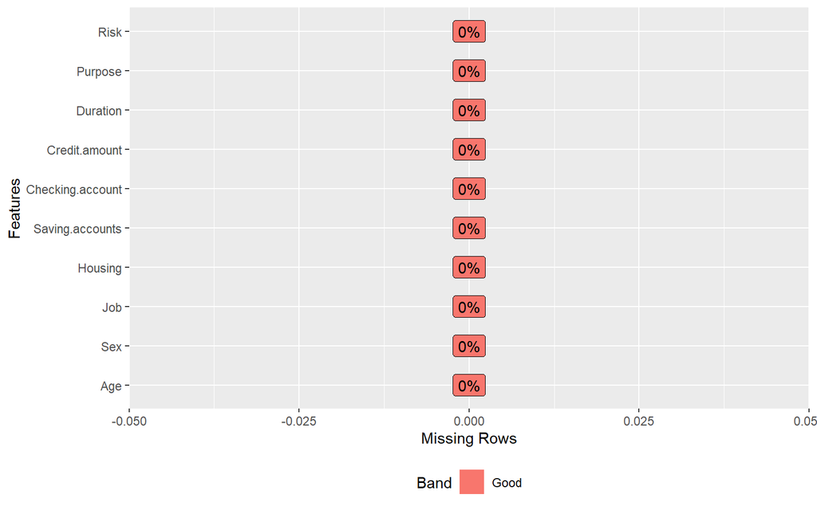

```r
# Check the missing data
plot_missing(df.nomis)
```

```r
class(df.nomis)
```

```
## [1] "data.frame"
```

```r
head(df.nomis)
```

```
##   Age    Sex Job Housing Saving.accounts Checking.account Credit.amount
## 1  67   male   2     own          little           little          1169
## 2  22 female   2     own          little         moderate          5951
## 3  49   male   1     own          little         moderate          2096
## 4  45   male   2    free          little           little          7882
## 5  53   male   2    free          little           little          4870
## 6  35   male   1    free          little         moderate          9055
##   Duration             Purpose Risk
## 1        6            radio/TV good
## 2       48            radio/TV  bad
## 3       12           education good
## 4       42 furniture/equipment good
## 5       24                 car  bad
## 6       36           education good
```

```r
# feature engineering
# Train/Test split for Regression
set.seed(42)
train1 <-createDataPartition(y=df.nomis$Credit.amount,p=0.5,list=FALSE)

train <- df.nomis[train1, ]

test <- df.nomis[-train1, ]
```

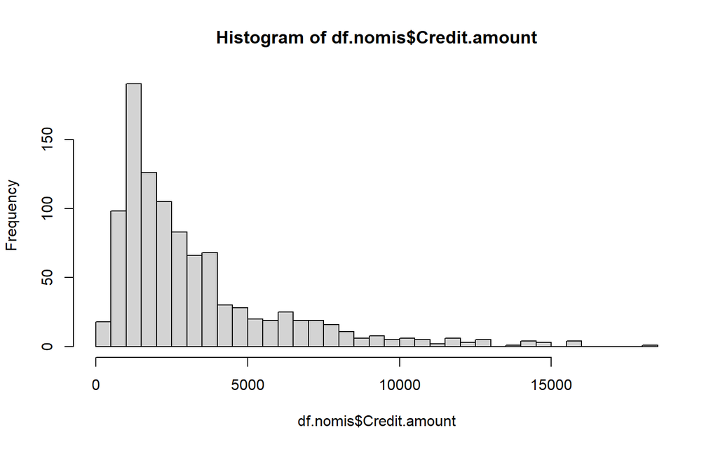

```r
hist(df.nomis$Credit.amount,breaks=50)
```

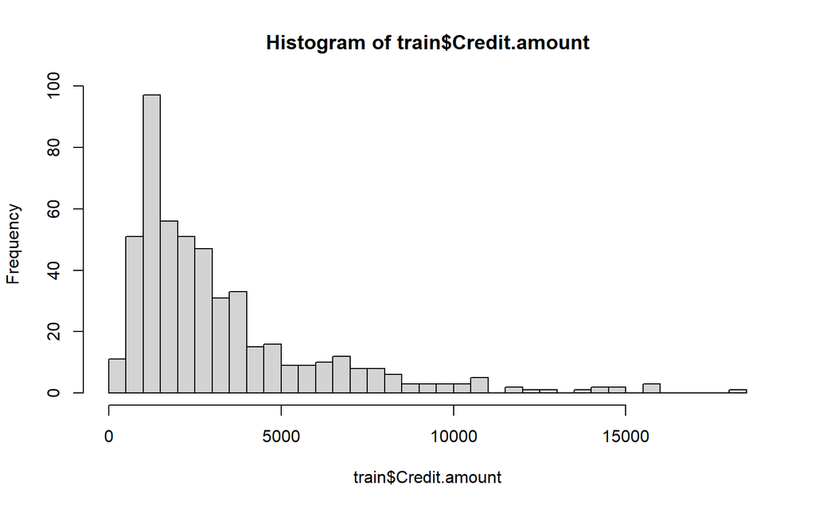

```r
# Split dependent variable distribution
hist(train$Credit.amount,breaks=50)
```

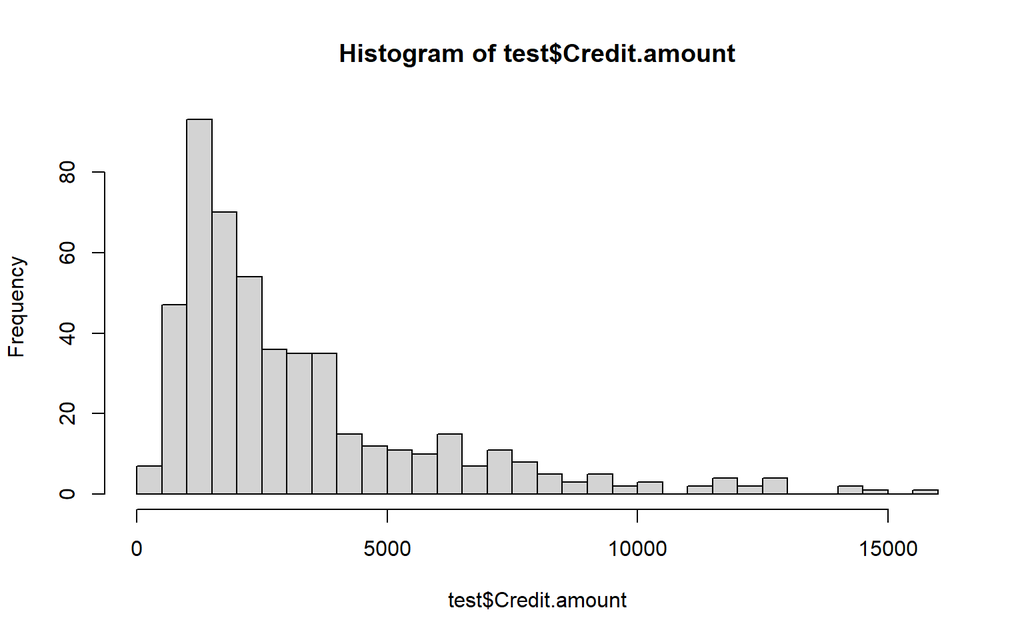

```r
hist(test$Credit.amount,breaks=50)
```

```r
# fold cross validation
train_control <- trainControl(method="cv", number=10)
```

### 4.1.1 simple linear regression model

```r
fit <- lm(Credit.amount ~ Age,data = df.nomis)
summary(fit)
```

```
##
## Call:
## lm(formula = Credit.amount ~ Age, data = df.nomis)
##
## Residuals:
##     Min      1Q  Median      3Q     Max
## -3068.5 -1895.6  -955.6   717.9 15181.5
##
## Coefficients:
##             Estimate Std. Error t value Pr(>|t|)
## (Intercept) 2982.684    292.985  10.180   <2e-16 ***
## Age            8.118      7.851   1.034    0.301
## ---
## Signif. codes:  0 '***' 0.001 '**' 0.01 '*' 0.05 '.' 0.1 ' ' 1
##
## Residual standard error: 2823 on 998 degrees of freedom
## Multiple R-squared:  0.00107,    Adjusted R-squared:  6.943e-05
## F-statistic: 1.069 on 1 and 998 DF,  p-value: 0.3013
```

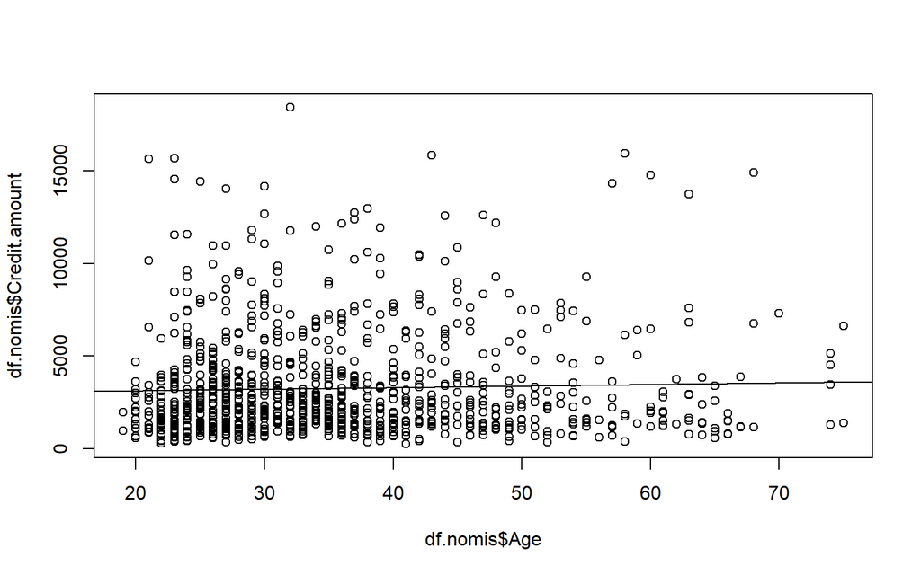

```r
plot(df.nomis$Age,df.nomis$Credit.amount)
abline(fit)
```